# team

Xinyi Zhu, Han Sun

3/21/2020

Part 1 Cleaning Data Frame

```r
library(ggplot2)
library(classdata)
library(dplyr)
library(tidyr)
library(readxl)
# import defense sheet
defense <- read_excel('/Users/jessie/Desktop/ds202/cyclonesFootball2019.xlsx', sheet='Defensive')
str(defense)
```

```
## Classes 'tbl_df', 'tbl' and 'data.frame':    502 obs. of  11 variables:
##  $ Name             : chr  "White, Lawrence" "White, Lawrence" "White, Lawrence" "White, Lawrence" ...
##  $ Opponent_Opponent: chr  "UNI" "Iowa" "ULM" "Baylor" ...
##  $ Tackles_Solo     : chr  "4" "4" "3" "4" ...
##  $ Tackles_ASST     : chr  "4" "7" "5" "2" ...
##  $ Tackles_TFL      : chr  "0" "0" "0" "0" ...
##  $ Tackles_Sack     : chr  "0" "0" "0" "0" ...
##  $ Turnover_FF      : chr  "0" "0" "0" "0" ...
##  $ Turnover_FR      : chr  "0" "0" "0" "0" ...
##  $ Turnover_INT     : chr  "0" "0" "1" "0" ...
##  $ Pass_QBH         : chr  "1" "0" "0" "0" ...
##  $ Pass_PB          : chr  "1" "2" "0" "0" ...
```

```r
# import offense sheet
offense <- read_excel('/Users/jessie/Desktop/ds202/cyclonesFootball2019.xlsx', sheet='Offensive')
str(offense)
```

```
## Classes 'tbl_df', 'tbl' and 'data.frame':    195 obs. of  12 variables:
##  $ Name             : chr  "Akers, Landen" "Akers, Landen" "Akers, Landen" "Akers, Landen" ...
##  $ Opponent_Opponent: chr  "UNI" "Iowa" "ULM" "Baylor" ...
##  $ Rushing_ATT      : chr  "0" "0" "1" "0" ...
##  $ Rushing_YDS      : chr  "0" "0" "8" "0" ...
##  $ Rushing_TD       : chr  "0" "0" "0" "0" ...
##  $ Receiving_REC    : chr  "1" "0" "0" "0" ...
##  $ Receiving_YDS    : chr  "21" "0" "0" "0" ...
##  $ Receiving_TD     : chr  "0" "0" "0" "0" ...
##  $ Passing_CMP-ATT  : chr  NA NA NA NA ...
##  $ Passing_YDS      : chr  NA NA NA NA ...
##  $ Passing_TD       : chr  NA NA NA NA ...
##  $ Passing_INT      : chr  NA NA NA NA ...
```

```r
# import biography sheet
biography <- read_excel('/Users/jessie/Desktop/ds202/cyclonesFootball2019.xlsx', sheet='Biography')
str(biography)
```

```
## Classes 'tbl_df', 'tbl' and 'data.frame':    105 obs. of  7 variables:
##  $ Name      : chr  "Akers, Landen" "Allen, Chase" "Anderson, Ezeriah" "Assalley, Connor" ...
##  $ Position  : chr  "Wide Receiver" "Tight End" "Wide Receiver" "Placekicker" ...
##  $ Height    : chr  "6-0" "6-7" "6-5" "6-0" ...
##  $ Weight    : chr  "188" "245" "204" "195" ...
##  $ Class     : chr  "Redshirt Senior" "Redshirt Senior" "Redshirt Freshman" "Redshirt Senior" ...
##  $ Hometown  : chr  "Cedar Rapids, Iowa" "Nixa, Mo." "Seffner, Fla." "Naperville, Ill." ...
##  $ Highschool: chr  "Washington" "Nixa" "Armwood" "Central" ...
```

The player names and opponent names are factors.

```r
defense$Name <- factor(defense$Name)
defense$Opponent_Opponent <- factor(defense$Opponent_Opponent)
str(defense)
```

```
## Classes 'tbl_df', 'tbl' and 'data.frame':    502 obs. of  11 variables:
##  $ Name             : Factor w/ 43 levels "Akers, Landen",..: 40 40 40 40 40 40 40 40 40 40 ...
##  $ Opponent_Opponent: Factor w/ 13 levels "Baylor","Iowa",..: 12 2 11 1 8 13 10 7 6 9 ...
##  $ Tackles_Solo     : chr  "4" "4" "3" "4" ...
##  $ Tackles_ASST     : chr  "4" "7" "5" "2" ...
##  $ Tackles_TFL      : chr  "0" "0" "0" "0" ...
##  $ Tackles_Sack     : chr  "0" "0" "0" "0" ...
##  $ Turnover_FF      : chr  "0" "0" "0" "0" ...
##  $ Turnover_FR      : chr  "0" "0" "0" "0" ...
##  $ Turnover_INT     : chr  "0" "0" "1" "0" ...
##  $ Pass_QBH         : chr  "1" "0" "0" "0" ...
##  $ Pass_PB          : chr  "1" "2" "0" "0" ...
```

```r
offense$Name <- factor(offense$Name)
offense$Opponent_Opponent <- factor(offense$Opponent_Opponent)
str(offense)
```

```
## Classes 'tbl_df', 'tbl' and 'data.frame':    195 obs. of  12 variables:
##  $ Name             : Factor w/ 17 levels "Akers, Landen",..: 1 1 1 1 1 1 1 1 1 1 ...
##  $ Opponent_Opponent: Factor w/ 13 levels "Baylor","Iowa",..: 12 2 11 1 8 13 10 7 6 9 ...
##  $ Rushing_ATT      : chr  "0" "0" "1" "0" ...
##  $ Rushing_YDS      : chr  "0" "0" "8" "0" ...
##  $ Rushing_TD       : chr  "0" "0" "0" "0" ...
##  $ Receiving_REC    : chr  "1" "0" "0" "0" ...
##  $ Receiving_YDS    : chr  "21" "0" "0" "0" ...
##  $ Receiving_TD     : chr  "0" "0" "0" "0" ...
##  $ Passing_CMP-ATT  : chr  NA NA NA NA ...
##  $ Passing_YDS      : chr  NA NA NA NA ...
##  $ Passing_TD       : chr  NA NA NA NA ...
##  $ Passing_INT      : chr  NA NA NA NA ...
```

All offensive and defensive statistics are numerical. The Weight column in biogrpahy is also numeric.

```r
defClean <- defense %>%
  mutate(Tackles_Solo = as.numeric(Tackles_Solo),
         Tackles_ASST = as.numeric(Tackles_ASST),
         Tackles_TFL = as.numeric(Tackles_TFL),
         Tackles_Sack = as.numeric(Tackles_Sack),
         Turnover_FF = as.numeric(Turnover_FF),
         Turnover_FR = as.numeric(Turnover_FR),
         Turnover_INT = as.numeric(Turnover_INT),
         Pass_QBH = as.numeric(Pass_QBH),
         Pass_PB = as.numeric(Pass_PB))
str(defClean)
```

```
## Classes 'tbl_df', 'tbl' and 'data.frame':    502 obs. of  11 variables:
##  $ Name             : Factor w/ 43 levels "Akers, Landen",..: 40 40 40 40 40 40 40 40 40 40 ...
##  $ Opponent_Opponent: Factor w/ 13 levels "Baylor","Iowa",..: 12 2 11 1 8 13 10 7 6 9 ...
##  $ Tackles_Solo     : num  4 4 3 4 3 1 7 3 6 5 ...
##  $ Tackles_ASST     : num  4 7 5 2 2 1 1 2 1 5 ...
##  $ Tackles_TFL      : num  0 0 0 0 1 0 0 0 1 1 ...
##  $ Tackles_Sack     : num  0 0 0 0 0 0 0 0 0 1 ...
##  $ Turnover_FF      : num  0 0 0 0 0 0 0 0 0 0 ...
##  $ Turnover_FR      : num  0 0 0 0 0 0 0 0 0 0 ...
##  $ Turnover_INT     : num  0 0 1 0 0 0 0 0 1 0 ...
##  $ Pass_QBH         : num  1 0 0 0 0 0 0 0 1 0 ...
##  $ Pass_PB          : num  1 2 0 0 0 1 0 0 0 0 ...
```

```r
offense$Name <- factor(offense$Name)
offense$Opponent_Opponent <- factor(offense$Opponent_Opponent)
names(offense)[9] <- "Passing_CMP_ATT"
offClean <- offense %>%
  mutate(Rushing_ATT = as.numeric(Rushing_ATT),
         Rushing_YDS = as.numeric(Rushing_YDS),
         Rushing_TD = as.numeric(Rushing_TD),
         Receiving_REC = as.numeric(Receiving_REC),
         Receiving_YDS = as.numeric(Receiving_YDS),
         Receiving_TD = as.numeric(Receiving_TD),
         Passing_CMP_ATT = as.numeric(Passing_CMP_ATT),
         Passing_YDS = as.numeric(Passing_YDS),
         Passing_TD = as.numeric(Passing_TD),
         Passing_INT = as.numeric(Passing_INT))
names(offense)[9] <- "Passing_CMP_ATT"
offClean[is.na(offClean)] = 0
str(offClean)
```

```
## Classes 'tbl_df', 'tbl' and 'data.frame':    195 obs. of  12 variables:
##  $ Name             : Factor w/ 17 levels "Akers, Landen",..: 1 1 1 1 1 1 1 1 1 1 ...
##  $ Opponent_Opponent: Factor w/ 13 levels "Baylor","Iowa",..: 12 2 11 1 8 13 10 7 6 9 ...
##  $ Rushing_ATT      : num  0 0 1 0 0 0 0 0 0 0 ...
##  $ Rushing_YDS      : num  0 0 8 0 0 0 0 0 0 0 ...
##  $ Rushing_TD       : num  0 0 0 0 0 0 0 0 0 0 ...
##  $ Receiving_REC    : num  1 0 0 0 1 0 0 4 0 1 ...
##  $ Receiving_YDS    : num  21 0 0 0 32 0 0 39 0 7 ...
##  $ Receiving_TD     : num  0 0 0 0 0 0 0 0 0 0 ...
##  $ Passing_CMP_ATT  : num  0 0 0 0 0 0 0 0 0 0 ...
##  $ Passing_YDS      : num  0 0 0 0 0 0 0 0 0 0 ...
##  $ Passing_TD       : num  0 0 0 0 0 0 0 0 0 0 ...
##  $ Passing_INT      : num  0 0 0 0 0 0 0 0 0 0 ...
```

```r
bioClean <- biography %>%
  mutate(Weight = as.numeric(Weight))
str(bioClean)
```

```
## Classes 'tbl_df', 'tbl' and 'data.frame':    105 obs. of  7 variables:
##  $ Name      : chr  "Akers, Landen" "Allen, Chase" "Anderson, Ezeriah" "Assalley, Connor" ...
##  $ Position  : chr  "Wide Receiver" "Tight End" "Wide Receiver" "Placekicker" ...
##  $ Height    : chr  "6-0" "6-7" "6-5" "6-0" ...
##  $ Weight    : num  188 245 204 195 190 235 255 285 300 215 ...
##  $ Class     : chr  "Redshirt Senior" "Redshirt Senior" "Redshirt Freshman" "Redshirt Senior" ...
##  $ Hometown  : chr  "Cedar Rapids, Iowa" "Nixa, Mo." "Seffner, Fla." "Naperville, Ill." ...
##  $ Highschool: chr  "Washington" "Nixa" "Armwood" "Central" ...
```

Change the Height column in biogrpahy into numeric.

```r
bioClean<-biography %>% separate(Height, into = c("feet", "inch"))
bioClean <- bioClean %>%
  mutate(feet = as.numeric(feet),
         inch = as.numeric(inch))
bioClean$Height <- bioClean$feet+bioClean$inch/12
bioClean
```

```
## # A tibble: 105 x 9
##    Name      Position   feet  inch Weight Class    Hometown    Highschool Height
##    <chr>     <chr>     <dbl> <dbl> <chr>  <chr>    <chr>       <chr>       <dbl>
##  1 Akers, L… Wide Rec…     6     0 188    Redshir… Cedar Rapi… Washington   6
##  2 Allen, C… Tight End     6     7 245    Redshir… Nixa, Mo.   Nixa         6.58
##  3 Anderson… Wide Rec…     6     5 204    Redshir… Seffner, F… Armwood      6.42
##  4 Assalley… Placekic…     6     0 195    Redshir… Naperville… Central      6
##  5 Azunna, … Defensiv…     6     0 190    Redshir… Grand Prai… Lake Ridge   6
##  6 Bailey, … Defensiv…     6     3 235    Redshir… Clarksdale… Clarksdale   6.25
##  7 Bailey, … Defensiv…     6     2 255    Redshir… Jacksonvil… Raines       6.17
##  8 Bailey, … Defensiv…     6     2 285    Redshir… Jacksonvil… Raines       6.17
##  9 Bankston… Defensiv…     6     0 300    Junior   Woodstock,… Woodstock    6
## 10 Bouman, … Quarterb…     6     6 215    Freshman Buffalo, M… Buffalo      6.5
## # … with 95 more rows
```

By cleaning the three data frames in R, at the end of this step you should have the following three clean data frames: defClean, offClean, and bioClean. Print the structures of these data frames.

```r
defClean
```

```
## # A tibble: 502 x 11
##    Name  Opponent_Oppone… Tackles_Solo Tackles_ASST Tackles_TFL Tackles_Sack
##    <fct> <fct>                   <dbl>        <dbl>       <dbl>        <dbl>
##  1 Whit… UNI                         4            4           0            0
##  2 Whit… Iowa                        4            7           0            0
##  3 Whit… ULM                         3            5           0            0
##  4 Whit… Baylor                      4            2           0            0
##  5 Whit… TCU                         3            2           1            0
##  6 Whit… West Virginia               1            1           0            0
##  7 Whit… Texas Tech                  7            1           0            0
##  8 Whit… Oklahoma State              3            2           0            0
##  9 Whit… Oklahoma                    6            1           1            0
## 10 Whit… Texas                       5            5           1            1
## # … with 492 more rows, and 5 more variables: Turnover_FF <dbl>,
## #   Turnover_FR <dbl>, Turnover_INT <dbl>, Pass_QBH <dbl>, Pass_PB <dbl>
```

```r
offClean
```

```
## # A tibble: 195 x 12
##    Name  Opponent_Oppone… Rushing_ATT Rushing_YDS Rushing_TD Receiving_REC
##    <fct> <fct>                  <dbl>       <dbl>      <dbl>         <dbl>
##  1 Aker… UNI                        0           0          0             1
##  2 Aker… Iowa                       0           0          0             0
##  3 Aker… ULM                        1           8          0             0
##  4 Aker… Baylor                     0           0          0             0
##  5 Aker… TCU                        0           0          0             1
##  6 Aker… West Virginia              0           0          0             0
##  7 Aker… Texas Tech                 0           0          0             0
##  8 Aker… Oklahoma State             0           0          0             4
##  9 Aker… Oklahoma                   0           0          0             0
## 10 Aker… Texas                      0           0          0             1
## # … with 185 more rows, and 6 more variables: Receiving_YDS <dbl>,
## #   Receiving_TD <dbl>, Passing_CMP_ATT <dbl>, Passing_YDS <dbl>,
## #   Passing_TD <dbl>, Passing_INT <dbl>
```

```r
bioClean
```

```
## # A tibble: 105 x 9
##    Name      Position   feet  inch Weight Class    Hometown    Highschool Height
##    <chr>     <chr>     <dbl> <dbl> <chr>  <chr>    <chr>       <chr>       <dbl>
##  1 Akers, L… Wide Rec…     6     0 188    Redshir… Cedar Rapi… Washington   6
##  2 Allen, C… Tight End     6     7 245    Redshir… Nixa, Mo.   Nixa         6.58
##  3 Anderson… Wide Rec…     6     5 204    Redshir… Seffner, F… Armwood      6.42
##  4 Assalley… Placekic…     6     0 195    Redshir… Naperville… Central      6
##  5 Azunna, … Defensiv…     6     0 190    Redshir… Grand Prai… Lake Ridge   6
##  6 Bailey, … Defensiv…     6     3 235    Redshir… Clarksdale… Clarksdale   6.25
##  7 Bailey, … Defensiv…     6     2 255    Redshir… Jacksonvil… Raines       6.17
##  8 Bailey, … Defensiv…     6     2 285    Redshir… Jacksonvil… Raines       6.17
##  9 Bankston… Defensiv…     6     0 300    Junior   Woodstock,… Woodstock    6
## 10 Bouman, … Quarterb…     6     6 215    Freshman Buffalo, M… Buffalo      6.5
## # … with 95 more rows
```

Part two: Tidying

Reformat the defClean data frame into a tidy format using pivot_longer. The type of statistic (Tackles_Solo, Tackles_ASST, etc) is added as a new key column named Statistic.

```r
defClean1 <- defClean %>% pivot_longer(3:11, names_to = 'Statistic', values_to = 'score')
head(defClean1)
```

```
## # A tibble: 6 x 4
##   Name            Opponent_Opponent Statistic    score
##   <fct>           <fct>             <chr>        <dbl>
## 1 White, Lawrence UNI               Tackles_Solo     4
## 2 White, Lawrence UNI               Tackles_ASST     4
## 3 White, Lawrence UNI               Tackles_TFL      0
## 4 White, Lawrence UNI               Tackles_Sack     0
## 5 White, Lawrence UNI               Turnover_FF      0
## 6 White, Lawrence UNI               Turnover_FR      0
```

Part three: Joining data frames

1. Find where do the offensive players come from by joining the offensive data and player biography data appropriately.

```r
full<- full_join(offClean, bioClean, by = "Name")
full
```

```
## # A tibble: 287 x 20
##    Name  Opponent_Oppone… Rushing_ATT Rushing_YDS Rushing_TD Receiving_REC
##    <chr> <fct>                  <dbl>       <dbl>      <dbl>         <dbl>
##  1 Aker… UNI                        0           0          0             1
##  2 Aker… Iowa                       0           0          0             0
##  3 Aker… ULM                        1           8          0             0
##  4 Aker… Baylor                     0           0          0             0
##  5 Aker… TCU                        0           0          0             1
##  6 Aker… West Virginia              0           0          0             0
##  7 Aker… Texas Tech                 0           0          0             0
##  8 Aker… Oklahoma State             0           0          0             4
##  9 Aker… Oklahoma                   0           0          0             0
## 10 Aker… Texas                      0           0          0             1
## # … with 277 more rows, and 14 more variables: Receiving_YDS <dbl>,
## #   Receiving_TD <dbl>, Passing_CMP_ATT <dbl>, Passing_YDS <dbl>,
## #   Passing_TD <dbl>, Passing_INT <dbl>, Position <chr>, feet <dbl>,
## #   inch <dbl>, Weight <chr>, Class <chr>, Hometown <chr>, Highschool <chr>,
## #   Height <dbl>
```

2. Is there a relationship between the weight of a player and the receiving yards (Receiving_YDS)?

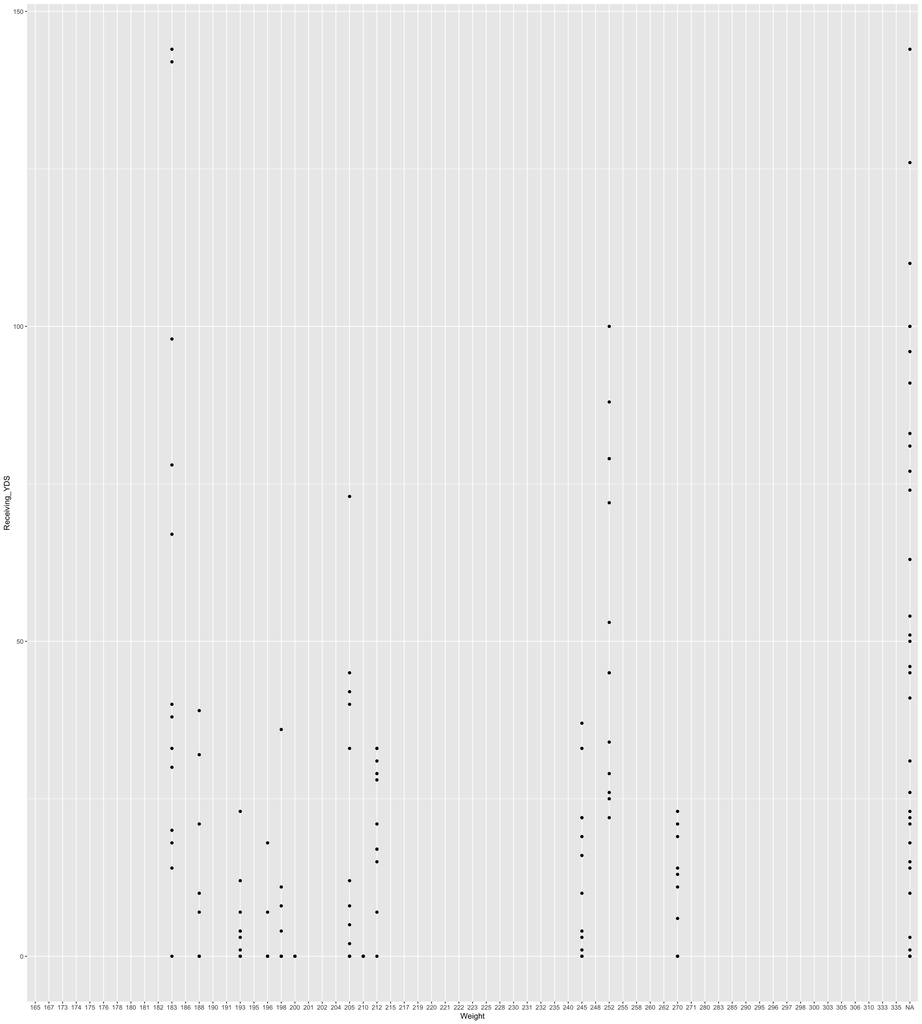

```r
ggplot(data =full, aes(x = Weight, y = Receiving_YDS)) +
  geom_point()
```